[OHI Science](http://ohi-science.org) | [Citation policy](http://ohi-science.org/citation-policy/)

# OHI 2017: Ocean Acidification Data Prep

Compiled on Mon Apr 2 16:56:11 2018 by frazier

# Summary

NOTES: This follows the same methods as those used to generate the OHI pressure files (https://rawgit.com/OHI-Science/ohiprep/master/globalprep/prs_oa/v2017/create_oa_layer.html). The only difference is that a modified version of the ocean mask is used to mask the data in the final step.

# Data Source

**Reference**: [Feely et al.(2009)](https://darchive.mblwhoilibrary.org/bitstream/handle/1912/3180/22-4_feely.pdf?sequence=1&isAllowed=y)

**Downloaded**: July 19, 2017

**Description**: Aragonite Saturation State $\Omega_{arg}$

**Native data resolution**: 1 degree cells

**Time range**: 1880-1889 and 1958-2100, monthly data provided for each year. Future years are based on model projections for RCP 8.5. Previous years are hindcast/historical data.

**Format**: NetCDF

**Notes about the data**:

This data was shared with us by Ivan Lima from Woods Hole Institue for Oceanography in July 2017. The data came as NetCDFs with a resolution of about 1 degree. The data values are monthly average surface Ω aragonite saturation state.

# Methods

## Setup

```r
#set options for all chunks in code
knitr::opts_chunk$set(warning=FALSE, message=FALSE,fig.width=6, fig.height=6)

#libraries
library(raster)
library(ncdf4)
library(maps)
library(parallel)
library(foreach)
library(doParallel)
library(RColorBrewer)
library(stringr)

source("https://raw.githubusercontent.com/OHI-Science/ohiprep_v2018/master/src/R/spatial_common.R")
cols = rev(colorRampPalette(brewer.pal(11, 'Spectral'))(255)) # rainbow color scheme

# setwd("stressors/oa")

#define paths for the raw data and OA folder held on git-annex on our NCEAS server, Mazu

raw_dir    = file.path(dir_M, 'git-annex/globalprep/_raw_data')
oagit_dir  = file.path(dir_M, 'git-annex/globalprep/prs_oa')


# paralell processing
cl<-makeCluster(10)
registerDoParallel(cl)
```

## Resample & Land Mask

```r
files <- list.files(file.path(oagit_dir,'v2017/int/annual_avg_moll_rescaled_int'),
                    full.names = TRUE)

# not going to bother with the full data range
files <- files[grep(paste0(paste0("_", 1980:2017), collapse="|"), files)]

foreach(file = files)%dopar% {
#for(file in files){ # file=files[1] # for some reason cores weren't all working for me.  Did it the long way!
  yr <- substr(file, nchar(file)-7, nchar(file)-4)
  cat(yr)

  tmp <- raster(file)%>%
  resample(ocean, method = 'ngb') %>%
  mask(ocean, filename = file.path(dir_M, sprintf("git-annex/impact_acceleration/stressors/oa/final/oa_%s_rescaled_mol.tif", yr)), overwrite=TRUE)

  # check = raster(file.path(dir_M, "git-annex/impact_acceleration/stressors/oa/final/oa_1980_rescaled_mol.tif"))
  # plot(check)
}
```

# Final Pressure Layer

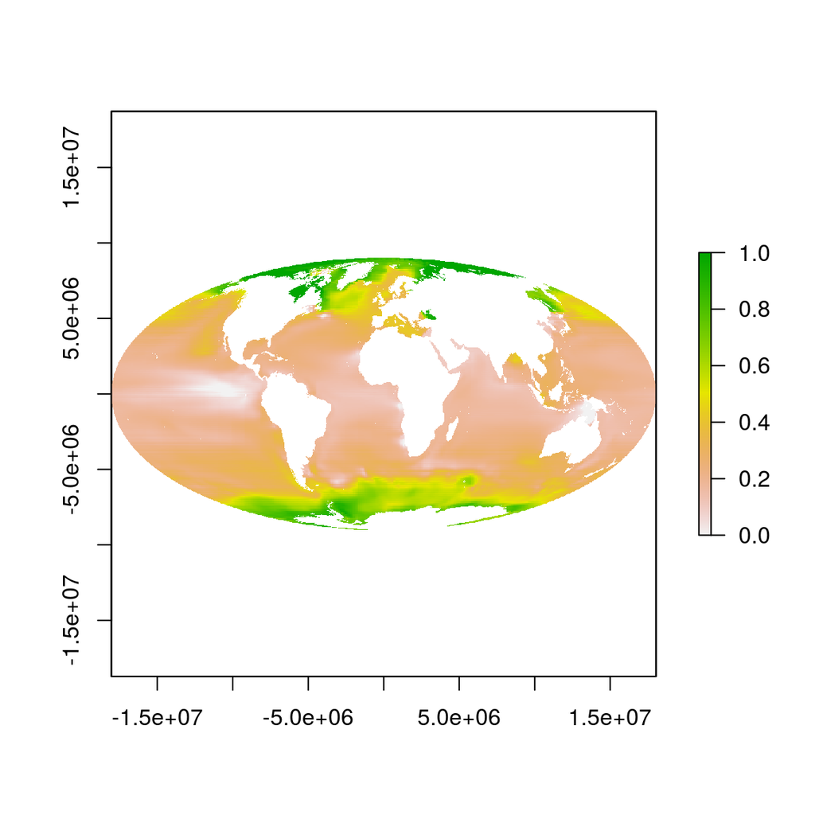

```r
plot(raster(file.path(dir_M, "git-annex/impact_acceleration/stressors/oa/final/oa_2016_rescaled_mol.tif"), box=FALSE, axes=FALSE, col=cols, main='Final Ocean Acidification \nPressure Layer 2016'))
```

# Gap-filled cells

We want to create a raster layer that shows all cells that were gap-filled. Since they were the same cells interpolated across all years, we only need to create one raster.

```r
#Rescaled data before interpolation
pre_int = raster(file.path(oagit_dir, 'v2017/int/annual_avg_moll_rescaled/oa_rescaled_2016.tif'))


pre_int[is.na(pre_int)] <- 999

resample(pre_int, ocean, method = "ngb") %>%
  mask(ocean, filename=file.path(dir_M, "git-annex/impact_acceleration/stressors/oa/int/oa_gf.tif"),
       overwrite = TRUE)
```

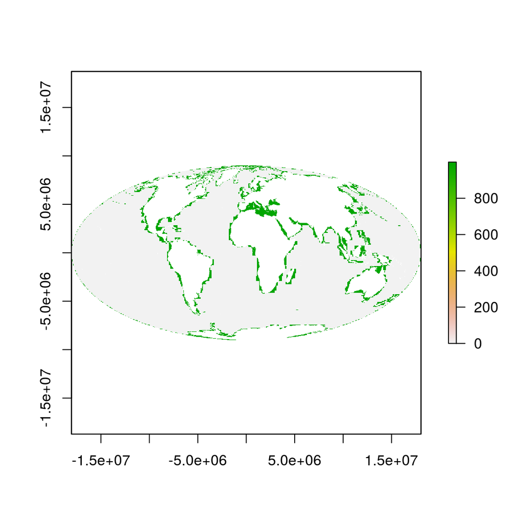

```r
plot(raster(file.path(dir_M, "git-annex/impact_acceleration/stressors/oa/int/oa_gf.tif")))
```

# Citation information

Woods Hole Oceanographic Institution. 2014 update to data originally published in: Feely, R.A., S.C. Doney, and S.R. Cooley. 2009. Ocean acidification: Present conditions and future changes in a high-CO2 world. Oceanography 22(4):36–47